# Assignment 3: Correlations, Differences, + Associations

Meghan Casey

September 24, 2020

### Variables of Interest

Unit of analysis: Household

Population: Renters in Massachusetts

1. Household Type (categorical): hh_type
2. Number of Units within Building (categorical): num_units
3. Age of Building (continuous): age_struct
4. Number of Bedrooms (continuous): bedrooms
5. Number of People (continuous): num_persons
6. Time Lived There (continuous): move_in
7. Gross Rent (continuous): gross_rent

#### Load Libraries

```r
library(tidyverse)
library(ggplot2)
library(ggthemes)
library(dbplyr)
library(dplyr)
```

#### Recode

##### Changed my household type thanks to Ryan’s code, didn’t think to make those more simple before!

```r
hh_data1 <- read_csv("households_ma.csv") %>%
   mutate(num_units = case_when(
    BLD_label=="2 Apartments"~"Fewer than\n10 apartments",
    BLD_label=="10-19 Apartments"~"10 to 49\napartments",
    BLD_label=="One-family house detached" ~ "Single-family",
    BLD_label=="3-4 Apartments" ~ "Fewer than\n10 apartments",
    BLD_label=="Mobile home or trailer" ~ "Mobile home\nor vehicle",
    BLD_label=="50 or more apartments" ~ "50+\napartments",
    BLD_label=="20-49 Apartments" ~ "10 to 49\napartments",
    BLD_label=="5-9 Apartments"~"Fewer than\n10 apartments",
    BLD_label=="One-family house attached" ~ "Single-family",
    BLD_label=="Boat, RV, van, etc." ~ "Mobile home\nor vehicle")) %>%
  mutate(hh_type = case_when(
    HHT_label =="Married couple household"~"Married\ncouple",
    HHT_label =="Other family household: Female householder, no spouse present"~"Single\nParent",
    HHT_label =="Other family household: Male householder, no spouse present"~"Single\nParent",
    HHT_label =="Nonfamily household: Male householder: Not living alone"~"Roommates",
    HHT_label =="Nonfamily household: Female householder: Not living alone"~"Roommates",
    HHT_label =="Nonfamily household: Female householder: Living alone"~"Living\nAlone",
    HHT_label =="Nonfamily household: Male householder: Living alone"~"Living\nAlone"))
```

### Relationships between two Continuous Variables

##### To Note: I had already created most of the plots before realizing I didn’t need to, so I left them in, but they aren’t all very interesting!

#### 1. Age of Building and Number of Bedrooms

```r
correlation1 <- cor.test(hh_data1$age_struct, hh_data1$bedrooms)
correlation1
```

```
##
##  Pearson's product-moment correlation
##
## data:  hh_data1$age_struct and hh_data1$bedrooms
## t = 14.625, df = 17920, p-value < 2.2e-16
## alternative hypothesis: true correlation is not equal to 0
## 95 percent confidence interval:
##  0.09411701 0.12305298
## sample estimates:
##      cor
## 0.108608
```

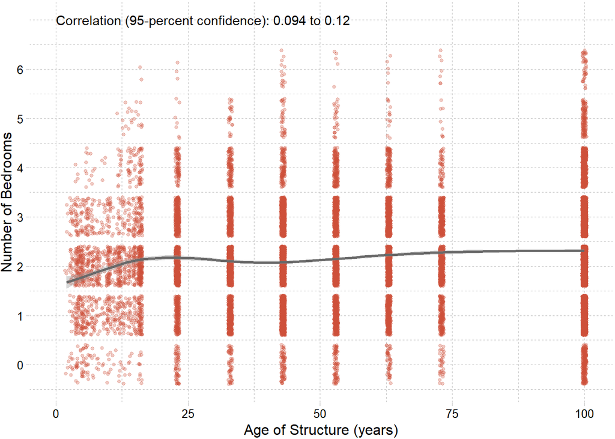

```r
ggplot(hh_data1, aes(x = age_struct, y = bedrooms)) +
  geom_point(size = 1, alpha = 0.3, position = "jitter", color = "tomato3") +
  theme_pander() +
  geom_smooth(color = "dimgray") +
  scale_x_continuous(name = "Age of Structure (years)") +
  scale_y_continuous(name = "Number of Bedrooms",
                     breaks = seq(0, 6, by = 1),
                     label = paste(prettyNum(seq(0, 6, by = 1)))) +

  annotate(geom = "text", x = 0, y = 7,
           label = paste("Correlation (95-percent confidence):",
                         prettyNum(correlation1$conf.int[1], digits = 2),
                         "to",
                         prettyNum(correlation1$conf.int[2], digits = 2)),
           hjust = 0)
```

##### Age of Building and Number of Bedrooms: weak (0.11 correlation), but statistically significant (p-value < 2.2e-16), positive correlation at a 95% confidence level.

#### 2. Age of Building and Number of People

```r
correlation2 <- cor.test(hh_data1$age_struct, hh_data1$num_persons)
correlation2
```

```
##
##  Pearson's product-moment correlation
##
## data:  hh_data1$age_struct and hh_data1$num_persons
## t = 6.0786, df = 17920, p-value = 1.237e-09
## alternative hypothesis: true correlation is not equal to 0
## 95 percent confidence interval:
##  0.03074136 0.05996241
## sample estimates:
##        cor
## 0.04536159
```

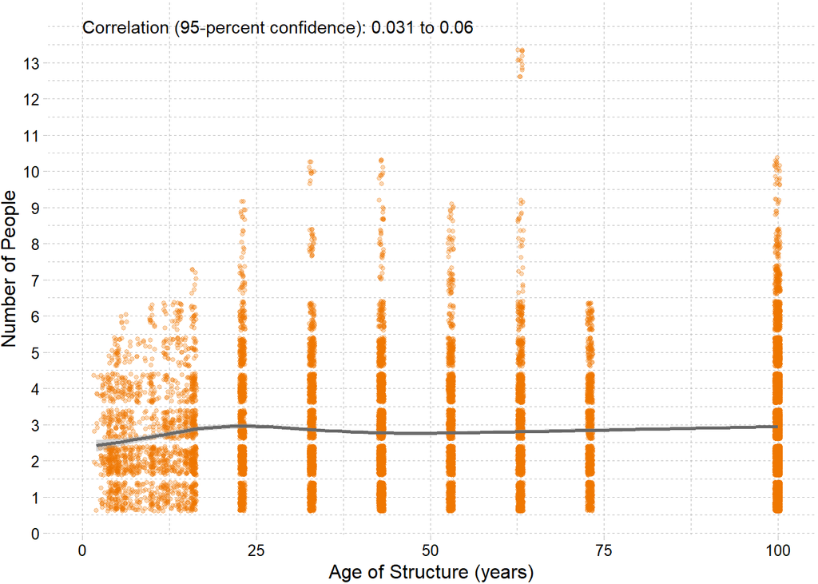

```r
ggplot(hh_data1, aes(x = age_struct, y = num_persons)) +
  geom_point(size = 1, alpha = 0.3, position = "jitter", color = "darkorange2") +
  theme_pander() +
  geom_smooth(color = "dimgray") +
  scale_x_continuous(name = "Age of Structure (years)") +
  scale_y_continuous(name = "Number of People",
                     breaks = seq(0, 13, by = 1),
                     label = paste(prettyNum(seq(0, 13, by = 1)))) +

  annotate(geom = "text", x = 0, y = 14,
           label = paste("Correlation (95-percent confidence):",
                         prettyNum(correlation2$conf.int[1], digits = 2),
                         "to",
                         prettyNum(correlation2$conf.int[2], digits = 2)),
           hjust = 0)
```

##### Age of Building and Number of People: weak (0.05 correlation), but statistically significant (p-value < 1.237e-09), positive correlation at a 95% confidence level.

#### 3. Age of Building and Time Lived There

```r
correlation3 <- cor.test(hh_data1$age_struct, hh_data1$move_in)
correlation3
```

```
##
##  Pearson's product-moment correlation
##
## data:  hh_data1$age_struct and hh_data1$move_in
## t = 14.589, df = 17920, p-value < 2.2e-16
## alternative hypothesis: true correlation is not equal to 0
## 95 percent confidence interval:
##  0.09385117 0.12278882
## sample estimates:
##       cor
## 0.1083429
```

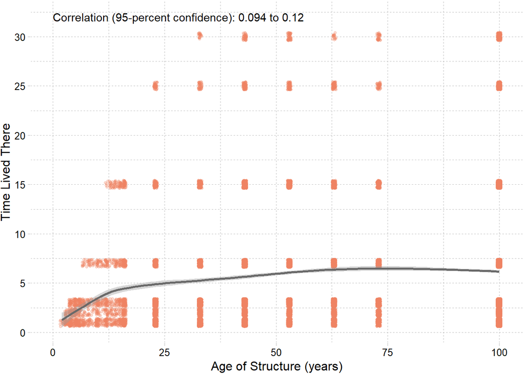

```r
ggplot(hh_data1, aes(x = age_struct, y = move_in)) +
  geom_point(size = 1, alpha = 0.3, position = "jitter", color = "salmon2") +
  geom_smooth(color = "dimgray") +
  theme_pander() +
  scale_x_continuous(name = "Age of Structure (years)") +
  scale_y_continuous(name = "Time Lived There",
                     breaks = seq(0, 30, by = 5),
                     label = paste(prettyNum(seq(0, 30, by = 5)))) +

  annotate(geom = "text", x = 0, y = 32,
           label = paste("Correlation (95-percent confidence):",
                         prettyNum(correlation3$conf.int[1], digits = 2),
                         "to",
                         prettyNum(correlation3$conf.int[2], digits = 2)),
           hjust = 0)
```

##### Age of Building and Time Lived There: weak (0.11 correlation), but statistically significant (p-value < 2.2e-16), positive correlation at a 95% confidence level.

#### 4. Gross Rent and Age of Building

```r
correlation4 <- cor.test(hh_data1$age_struct, hh_data1$gross_rent)
correlation4
```

```
##
##  Pearson's product-moment correlation
##
## data:  hh_data1$age_struct and hh_data1$gross_rent
## t = -12.913, df = 17920, p-value < 2.2e-16
## alternative hypothesis: true correlation is not equal to 0
## 95 percent confidence interval:
##  -0.11050435 -0.08149297
## sample estimates:
##         cor
## -0.09601905
```

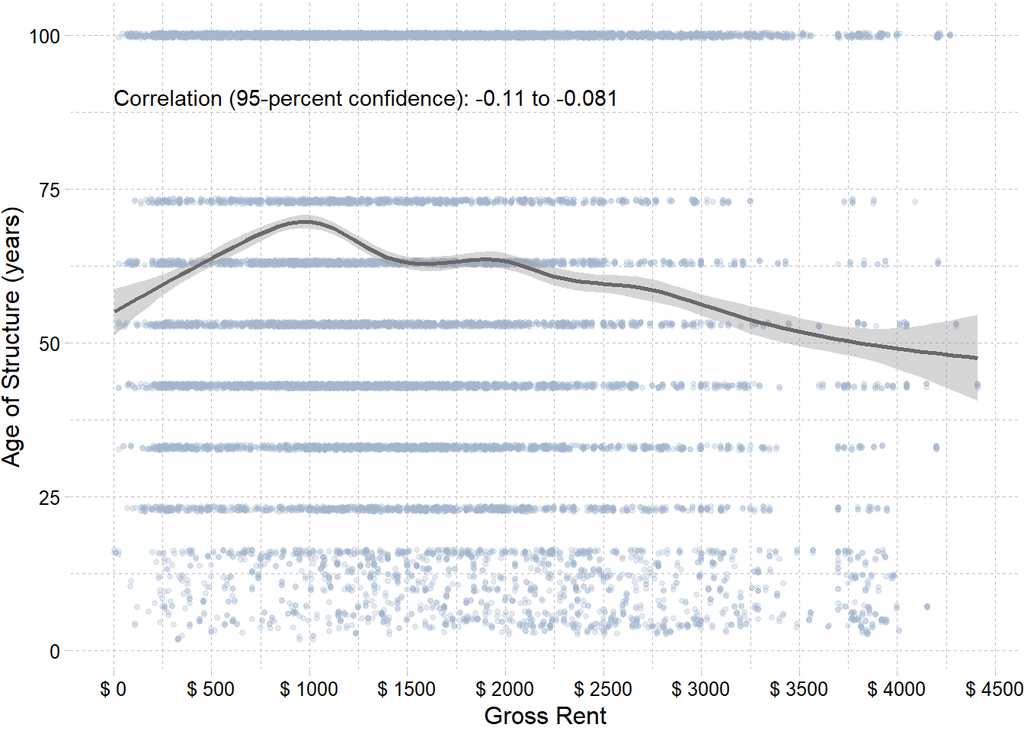

```r
ggplot(hh_data1, aes(x = gross_rent, y = age_struct)) +
  geom_point(size = 1, alpha = 0.3, position = "jitter", color = "lightsteelblue3") +
  geom_smooth(color = "dimgray") +
  theme_pander() +
  scale_y_continuous(name = "Age of Structure (years)") +
  scale_x_continuous(name = "Gross Rent",
                     breaks = seq(0, 4500, by = 500),
                     label = paste("$", (prettyNum(seq(0, 4500, by = 500))))) +

  annotate(geom = "text", x = 0, y = 90,
           label = paste("Correlation (95-percent confidence):",
                         prettyNum(correlation4$conf.int[1], digits = 2),
                         "to",
                         prettyNum(correlation4$conf.int[2], digits = 2)),
           hjust = 0)
```

#### 5. Number of Bedrooms and Number of People

```r
correlation5 <- cor.test(hh_data1$bedrooms, hh_data1$num_persons)
correlation5
```

```
##
##  Pearson's product-moment correlation
##
## data:  hh_data1$bedrooms and hh_data1$num_persons
## t = 92.253, df = 17920, p-value < 2.2e-16
## alternative hypothesis: true correlation is not equal to 0
## 95 percent confidence interval:
##  0.5574405 0.5772946
## sample estimates:
##     cor
## 0.56745
```

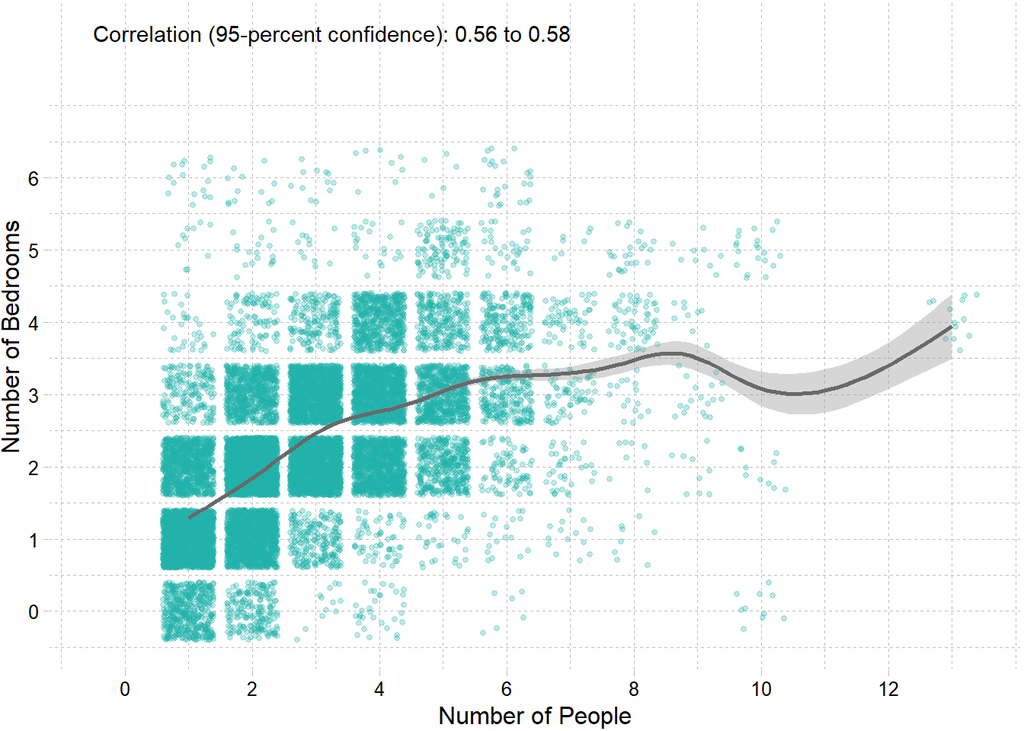

```r
ggplot(hh_data1, aes(x = num_persons, y = bedrooms)) +
  geom_point(size = 1, alpha = 0.3, position = "jitter", color = "lightseagreen") +
  geom_smooth(color = "dimgray") +
  theme_pander() +
  scale_x_continuous(name = "Number of People",
                     breaks = seq(0, 13, by = 2)) +
  scale_y_continuous(name = "Number of Bedrooms",
                     breaks = seq(0, 6, by = 1),
                     label = paste(prettyNum(seq(0, 6, by = 1)))) +

  annotate(geom = "text", x = -0.5, y = 8,
           label = paste("Correlation (95-percent confidence):",
                         prettyNum(correlation5$conf.int[1], digits = 2),
                         "to",
                         prettyNum(correlation5$conf.int[2], digits = 2)),
           hjust = 0)
```

##### Number of Bedrooms and Number of People: moderate (0.57 correlation), statistically significant (p-value < 2.2e-16), positive correlation at a 95% confidence level.

#### 6. Time Lived There and Number of Bedrooms

```r
correlation6 <- cor.test(hh_data1$bedrooms, hh_data1$move_in)
correlation6
```

```
##
##  Pearson's product-moment correlation
##
## data:  hh_data1$bedrooms and hh_data1$move_in
## t = 6.4104, df = 17920, p-value = 1.488e-10
## alternative hypothesis: true correlation is not equal to 0
## 95 percent confidence interval:
##  0.03321451 0.06242881
## sample estimates:
##        cor
## 0.04783189
```

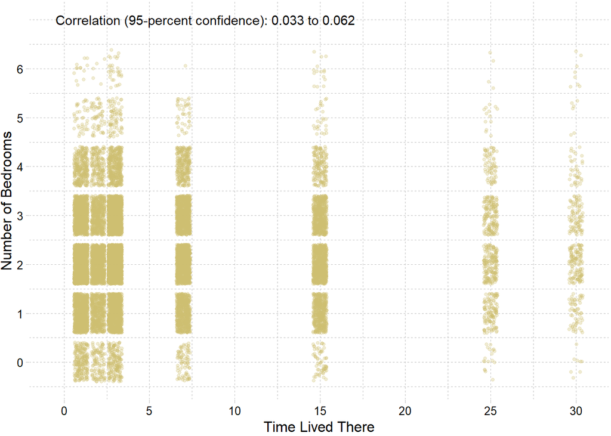

```r
ggplot(hh_data1, aes(x = move_in, y = bedrooms)) +
  geom_point(size = 1, alpha = 0.3, position = "jitter", color = "lightgoldenrod3") +
  theme_pander() +
  scale_x_continuous(name = "Time Lived There",
                     breaks = seq(0, 35, by = 5),
                     label = paste(prettyNum(seq(0, 35, by = 5)))) +
  scale_y_continuous(name = "Number of Bedrooms",
                     breaks = seq(0, 6, by = 1),
                     label = paste(prettyNum(seq(0, 6, by = 1)))) +

  annotate(geom = "text", x = -0.5, y = 7,
           label = paste("Correlation (95-percent confidence):",
                         prettyNum(correlation6$conf.int[1], digits = 2),
                         "to",
                         prettyNum(correlation6$conf.int[2], digits = 2)),
           hjust = 0)
```

##### Time Lived There and Number of Bedrooms: weak (0.05 correlation), but statistically significant (p-value < 1.488e-10), positive correlation at a 95% confidence level.

#### 7. Gross Rent and Number of Bedrooms

```r
correlation7 <- cor.test(hh_data1$bedrooms, hh_data1$gross_rent)
correlation7
```

```
##
##  Pearson's product-moment correlation
##
## data:  hh_data1$bedrooms and hh_data1$gross_rent
## t = 27.357, df = 17920, p-value < 2.2e-16
## alternative hypothesis: true correlation is not equal to 0
## 95 percent confidence interval:
##  0.1861278 0.2142355
## sample estimates:
##       cor
## 0.2002228
```

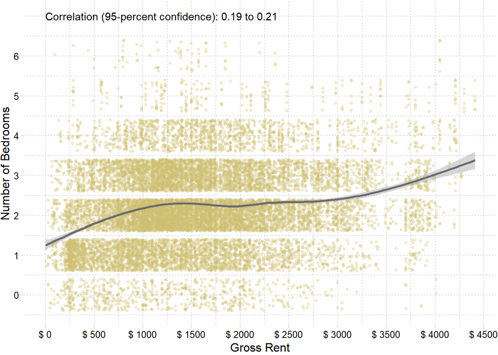

```r
ggplot(hh_data1, aes(x = gross_rent, y = bedrooms)) +
  geom_point(size = 1, alpha = 0.3, position = "jitter", color = "lightgoldenrod3") +
  geom_smooth(color = "dimgray") +
  theme_pander() +
  scale_x_continuous(name = "Gross Rent",
                     breaks = seq(0, 4500, by = 500),
                     label = paste("$", (prettyNum(seq(0, 4500, by = 500))))) +
  scale_y_continuous(name = "Number of Bedrooms",
                     breaks = seq(0, 6, by = 1),
                     label = paste(prettyNum(seq(0, 6, by = 1)))) +

  annotate(geom = "text", x = -0.5, y = 7,
           label = paste("Correlation (95-percent confidence):",
                         prettyNum(correlation7$conf.int[1], digits = 2),
                         "to",
                         prettyNum(correlation7$conf.int[2], digits = 2)),
           hjust = 0)
```

##### Gross Rent and Number of Bedrooms: weak (0.20 correlation), but statistically significant (p-value < 2.2e-16), positive correlation at a 95% confidence level.

#### 8. Time Lived There and Number of People

```r
correlation8 <- cor.test(hh_data1$num_persons, hh_data1$move_in)
correlation8
```

```
##
##  Pearson's product-moment correlation
##
## data:  hh_data1$num_persons and hh_data1$move_in
## t = -3.9386, df = 17920, p-value = 8.226e-05
## alternative hypothesis: true correlation is not equal to 0
## 95 percent confidence interval:
##  -0.04403124 -0.01477528
## sample estimates:
##         cor
## -0.02940956
```

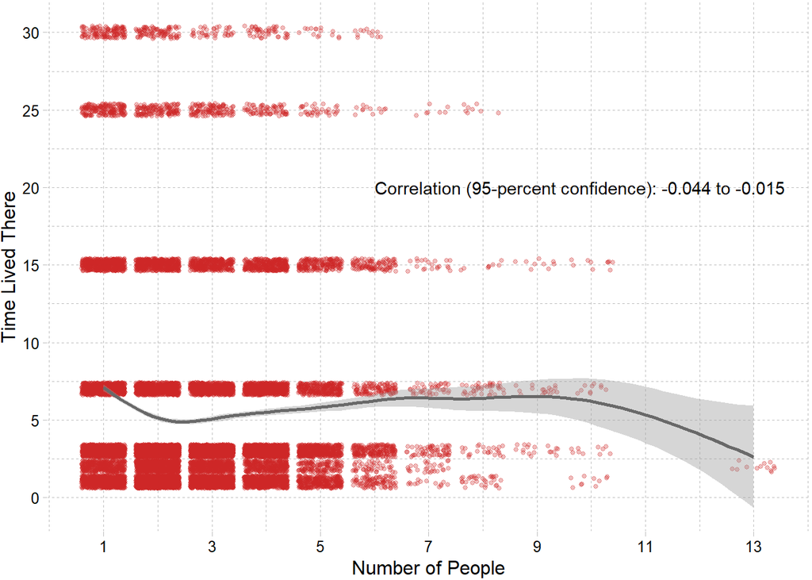

```r
ggplot(hh_data1, aes(x = num_persons, y = move_in)) +
  geom_point(size = 1, alpha = 0.3, position = "jitter", color = "firebrick3") +
  geom_smooth(color = "dimgray") +
  theme_pander() +
  scale_x_continuous(name = "Number of People",
                     breaks = seq(1, 13, by = 2)) +
  scale_y_continuous(name = "Time Lived There",
                     breaks = seq(0, 35, by = 5),
                     label = paste(prettyNum(seq(0, 35, by = 5)))) +

  annotate(geom = "text", x = 6, y = 20,
           label = paste("Correlation (95-percent confidence):",
                         prettyNum(correlation8$conf.int[1], digits = 2),
                         "to",
                         prettyNum(correlation8$conf.int[2], digits = 2)),
           hjust = 0)
```

##### Time Lived There and Number of People: weak (-0.03 correlation), but statistically significant (p-value < 8.226e-05), negative correlation at a 95% confidence level.

#### 9. Number of People and Gross Rent

```r
correlation9 <- cor.test(hh_data1$num_persons, hh_data1$gross_rent)
correlation9
```

```
##
##  Pearson's product-moment correlation
##
## data:  hh_data1$num_persons and hh_data1$gross_rent
## t = 21.053, df = 17920, p-value < 2.2e-16
## alternative hypothesis: true correlation is not equal to 0
## 95 percent confidence interval:
##  0.1410429 0.1696176
## sample estimates:
##       cor
## 0.1553628
```

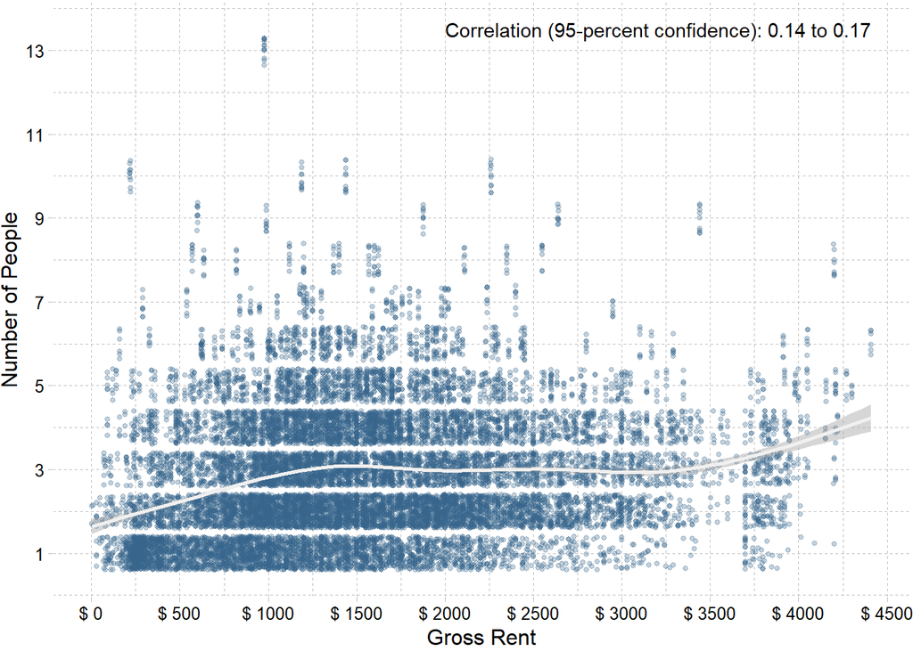

```r
ggplot(hh_data1, aes(x = gross_rent, y = num_persons)) +
  geom_point(size = 1, alpha = 0.3, position = "jitter", color = "steelblue4") +
  geom_smooth(color = "gray94") +
  theme_pander() +
  scale_y_continuous(name = "Number of People",
                     breaks = seq(1, 13, by = 2)) +
  scale_x_continuous(name = "Gross Rent",
                     breaks = seq(0, 4500, by = 500),
                     label = paste("$", (prettyNum(seq(0, 4500, by = 500))))) +

  annotate(geom = "text", x = 2000, y = 13.5,
           label = paste("Correlation (95-percent confidence):",
                         prettyNum(correlation9$conf.int[1], digits = 2),
                         "to",
                         prettyNum(correlation9$conf.int[2], digits = 2)),
           hjust = 0)
```

##### Number of People and Gross Rent: weak (0.16 correlation), but statistically significant (p-value < 2.2e-16), positive correlation at a 95% confidence level.

#### 10. Time Lived There and Gross Rent

```r
correlation10 <- cor.test(hh_data1$move_in, hh_data1$gross_rent)
correlation10
```

```
##
##  Pearson's product-moment correlation
##
## data:  hh_data1$move_in and hh_data1$gross_rent
## t = -36.358, df = 17920, p-value < 2.2e-16
## alternative hypothesis: true correlation is not equal to 0
## 95 percent confidence interval:
##  -0.2756896 -0.2484196
## sample estimates:
##        cor
## -0.2621069
```

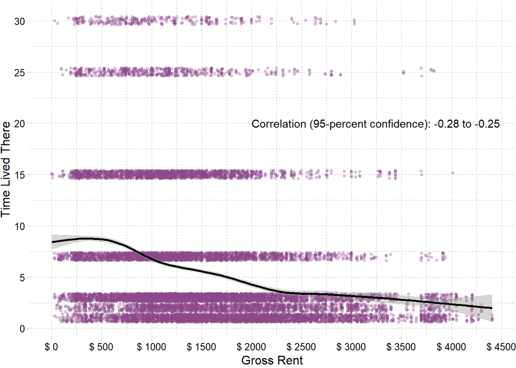

```r
ggplot(hh_data1, aes(x = gross_rent, y = move_in)) +
  geom_point(size = 1, alpha = 0.3, position = "jitter", color = "orchid4") +
  geom_smooth(color = "black") +
  theme_pander() +
  scale_y_continuous(name = "Time Lived There",
                     breaks = seq(0, 35, by = 5),
                     label = paste(prettyNum(seq(0, 35, by = 5)))) +
  scale_x_continuous(name = "Gross Rent",
                     breaks = seq(0, 4500, by = 500),
                     label = paste("$", (prettyNum(seq(0, 4500, by = 500))))) +

  annotate(geom = "text", x = 2000, y = 20,
           label = paste("Correlation (95-percent confidence):",
                         prettyNum(correlation10$conf.int[1], digits = 2),
                         "to",
                         prettyNum(correlation10$conf.int[2], digits = 2)),
           hjust = 0)
```

##### Time Lived There and Gross Rent: weak (-0.26 correlation), but statistically significant (p-value < 2.2e-16), negative correlation at a 95% confidence level.

### Relationship between two Categorical Variables

##### Thank you to Ryan again for his wise words on this heat map!

#### Household Type and Number of Units

```r
chi_sq <- chisq.test(hh_data1$hh_type, hh_data1$num_units)
chi_sq
```

```
##
##  Pearson's Chi-squared test
##
## data:  hh_data1$hh_type and hh_data1$num_units
## X-squared = 1540.8, df = 12, p-value < 2.2e-16
```

```r
chi_sq$observed
```

```
##                  hh_data1$num_units
## hh_data1$hh_type  10 to 49\napartments 50+\napartments
##   Living\nAlone                    920             899
##   Married\ncouple                  852             716
##   Roommates                        612             369
##   Single\nParent                   515             300
##                  hh_data1$num_units
## hh_data1$hh_type  Fewer than\n10 apartments Mobile home\nor vehicle
##   Living\nAlone                        1487                       9
##   Married\ncouple                      3125                       9
##   Roommates                            1979                      12
##   Single\nParent                       3017                      16
##                  hh_data1$num_units
## hh_data1$hh_type  Single-family
##   Living\nAlone             247
##   Married\ncouple          1425
##   Roommates                 433
##   Single\nParent            980
```

```r
chi_sq$expected
```

```
##                  hh_data1$num_units
## hh_data1$hh_type  10 to 49\napartments 50+\napartments
##   Living\nAlone               576.1767        453.9453
##   Married\ncouple             991.0821        780.8318
##   Roommates                   550.7809        433.9371
##   Single\nParent              780.9604        615.2858
##                  hh_data1$num_units
## hh_data1$hh_type  Fewer than\n10 apartments Mobile home\nor vehicle
##   Living\nAlone                    1909.591                9.142506
##   Married\ncouple                  3284.690               15.726035
##   Roommates                        1825.424                8.739538
##   Single\nParent                   2588.295               12.391921
##                  hh_data1$num_units
## hh_data1$hh_type  Single-family
##   Living\nAlone        613.1442
##   Married\ncouple     1054.6700
##   Roommates            586.1190
##   Single\nParent       831.0668
```

```r
difference_chi <- chi_sq$observed - chi_sq$expected

chi_dif_data <- as.data.frame(difference_chi)
```

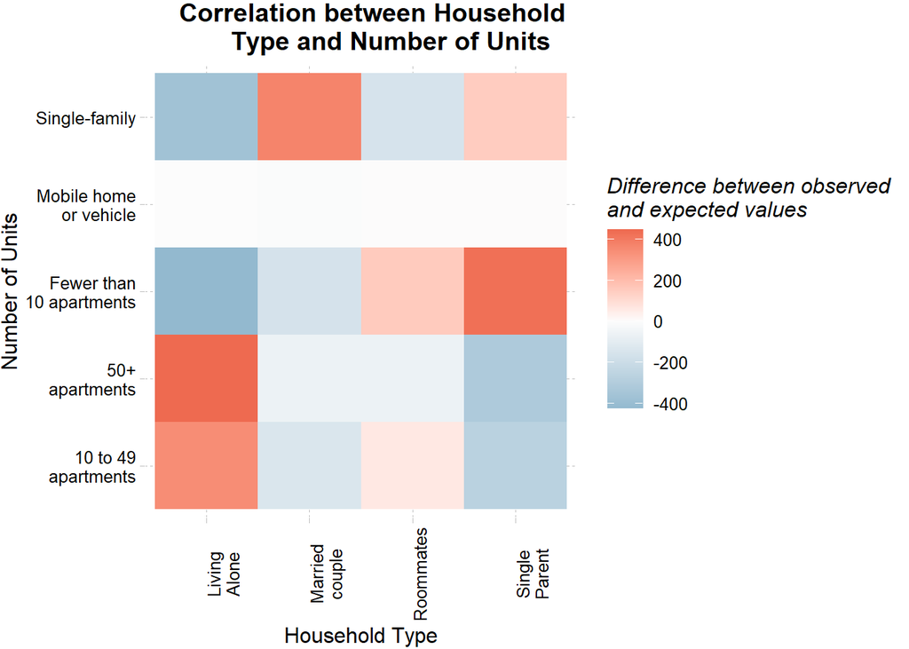

```r
chi_heatmap <- ggplot(chi_dif_data,
       aes(y = hh_data1.num_units,
           x = hh_data1.hh_type,
           fill = Freq)) +
  geom_tile() +
  scale_x_discrete(name = "Household Type") +
  scale_y_discrete(name = "Number of Units") +
  theme_pander()+
  theme(legend.key.size =  unit(0.7, "cm"),
        plot.title = element_text(hjust = 0.75),
        axis.text.x = element_text(angle = 90)) +
  scale_fill_gradient2(name = "Difference between observed \nand expected values",
                       midpoint=0,
                       low="lightskyblue3",
                       mid="gray99",
                       high="coral2") +
  ggtitle(label = "Correlation between Household\n Type and Number of Units")

chi_heatmap
```

### Relationship between a continuous variable and a categorical variable (three or more levels)

#### 1. Age of Building and Household Type

```r
anova1 <- aov(age_struct ~ hh_type, data = hh_data1)
summary(anova1)
```

```
##                Df   Sum Sq Mean Sq F value   Pr(>F)
## hh_type         3    45195   15065   14.48 2.02e-09 ***
## Residuals   17918 18634968    1040
## ---
## Signif. codes:  0 '***' 0.001 '**' 0.01 '*' 0.05 '.' 0.1 ' ' 1
```

```r
differences1 <- TukeyHSD(anova1)

as_tibble(cbind(pair = row.names(differences1$age_struct),
                differences1$hh_type))
```

```
## # A tibble: 6 x 4
##      diff    lwr   upr     `p adj`
##     <dbl>  <dbl> <dbl>       <dbl>
## 1  1.87    0.122  3.61 0.0305
## 2  4.12    2.13   6.11 0.000000629
## 3  4.05    2.22   5.88 0.000000115
## 4  2.25    0.481  4.02 0.00601
## 5  2.18    0.585  3.77 0.00252
## 6 -0.0725 -1.93   1.78 1.00
```

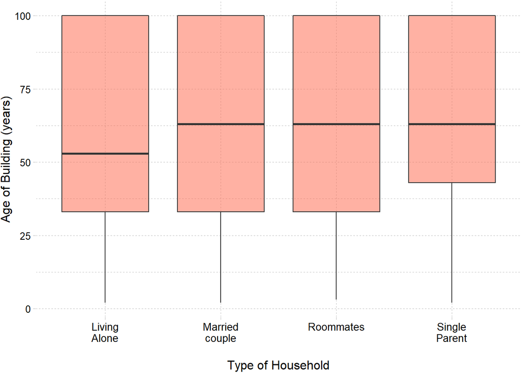

```r
ggplot(hh_data1, aes(x=hh_type , y = age_struct)) +
  geom_boxplot(fill = "tomato1", alpha = 0.5) +
  theme_pander() +
  theme(axis.text.x = element_text(size = 10)) +
  scale_x_discrete(name = "\nType of Household") +
  scale_y_continuous(name = "Age of Building (years)")
```

##### There is a statistically significant relationship between Household Type and Age of Building (2.02e-09). All but Single Parent households occupy the same range of ages of buildings.

#### 2. Age of Building and Number of Units

```r
anova2 <- aov(age_struct ~ num_units, data = hh_data1)
summary(anova2)
```

```
##                Df   Sum Sq Mean Sq F value Pr(>F)
## num_units       4  2284275  571069     624 <2e-16 ***
## Residuals   17917 16395887     915
## ---
## Signif. codes:  0 '***' 0.001 '**' 0.01 '*' 0.05 '.' 0.1 ' ' 1
```

```r
differences2 <- TukeyHSD(anova2)

as_tibble(cbind(pair = row.names(differences2$age_struct),
                differences2$num_units))
```

```
## # A tibble: 10 x 4
##       diff    lwr    upr      `p adj`
##      <dbl>  <dbl>  <dbl>        <dbl>
##  1 -13.6   -15.9  -11.3  0.0000000337
##  2  18.1    16.4   19.9  0.0000000337
##  3 -14.4   -26.6   -2.12 0.0121
##  4   4.59    2.46   6.72 0.0000000792
##  5  31.7    29.8   33.6  0.0000000337
##  6  -0.808 -13.1   11.5  1.00
##  7  18.2    15.9   20.4  0.0000000337
##  8 -32.5   -44.7  -20.3  0.0000000337
##  9 -13.5   -15.3  -11.8  0.0000000337
## 10  19.0     6.71  31.2  0.000236
```

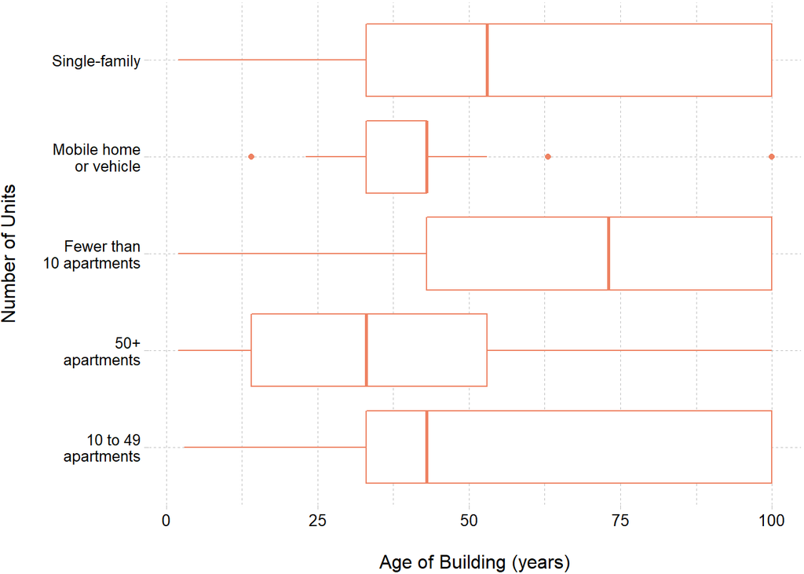

```r
ggplot(hh_data1, aes(y=num_units , x = age_struct)) +
  geom_boxplot(color = "salmon2") +
  theme_pander() +
  theme(axis.text.x = element_text(size = 10)) +
  scale_y_discrete(name = "Number of Units\n") +
  scale_x_continuous(name = "\nAge of Building (years)")
```

##### There is a statistically significant relationship between Number of Units and Age of Building (<2e-16). This box plot shows a few things: 1. Mobile home or vehicles have a small interquartile range and lower median than some of the unit categories, likely because the lifecycle of vehicles is less than buildings. 2. The lower median of 50+ apartments might relate to that style of housing becoming more popular recently, while other types have been common for much longer.

#### 3. Number of Bedrooms and Household Type

```r
anova3 <- aov(bedrooms ~ hh_type, data = hh_data1)
summary(anova3)
```

```
##                Df Sum Sq Mean Sq F value Pr(>F)
## hh_type         3   3840  1280.1    1439 <2e-16 ***
## Residuals   17918  15938     0.9
## ---
## Signif. codes:  0 '***' 0.001 '**' 0.01 '*' 0.05 '.' 0.1 ' ' 1
```

```r
differences3 <- TukeyHSD(anova3)

as_tibble(cbind(pair = row.names(differences3$bedrooms),
                differences3$hh_type))
```

```
## # A tibble: 6 x 4
##      diff    lwr      upr      `p adj`
##     <dbl>  <dbl>    <dbl>        <dbl>
## 1  1.07    1.02   1.12    0.0000000337
## 2  1.01    0.949  1.07    0.0000000337
## 3  1.29    1.24   1.35    0.0000000337
## 4 -0.0614 -0.113 -0.00960 0.0124
## 5  0.224   0.177  0.271   0.0000000337
## 6  0.285   0.231  0.340   0.0000000337
```

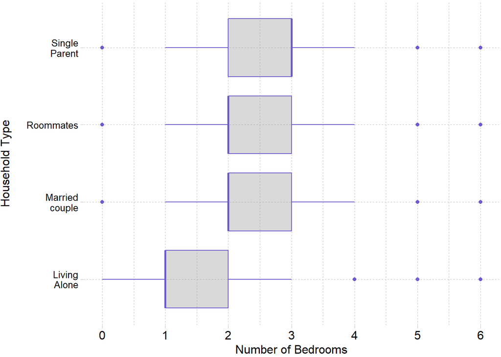

```r
ggplot(hh_data1, aes(x=bedrooms , y = hh_type)) +
  geom_boxplot(color = "slateblue", fill = "dimgray", alpha = 0.25) +
  theme_pander() +
  theme(axis.text.x = element_text(size = 12)) +
  scale_x_continuous(name = "Number of Bedrooms",
                     breaks = seq(0,6, by =1)) +
  scale_y_discrete(name = "Household Type\n")
```

##### There is a statistically significant relationship between Household Type and Number of Bedrooms (<2e-16). This relationship is shown in the box plot, with all but living along having the same interquartile range, but it would make sense for a lone person to require fewer bedrooms. There are also several outliers in each category, something that could be interesting to look into.

#### 4. Number of Bedrooms and Number of Units

```r
anova4 <- aov(bedrooms ~ num_units, data = hh_data1)
summary(anova4)
```

```
##                Df Sum Sq Mean Sq F value Pr(>F)
## num_units       4   4186  1046.6    1203 <2e-16 ***
## Residuals   17917  15592     0.9
## ---
## Signif. codes:  0 '***' 0.001 '**' 0.01 '*' 0.05 '.' 0.1 ' ' 1
```

```r
differences4 <- TukeyHSD(anova4)

as_tibble(cbind(pair = row.names(differences4$bedrooms),
                differences4$num_units))
```

```
## # A tibble: 10 x 4
##      diff    lwr    upr      `p adj`
##     <dbl>  <dbl>  <dbl>        <dbl>
##  1 -0.175 -0.246 -0.104 0.0000000339
##  2  0.788  0.735  0.842 0.0000000337
##  3  0.645  0.267  1.02  0.0000324
##  4  1.28   1.22   1.35  0.0000000337
##  5  0.963  0.904  1.02  0.0000000337
##  6  0.820  0.441  1.20  0.0000000703
##  7  1.46   1.39   1.53  0.0000000337
##  8 -0.143 -0.519  0.233 0.837
##  9  0.495  0.442  0.547 0.0000000337
## 10  0.638  0.260  1.02  0.0000409
```

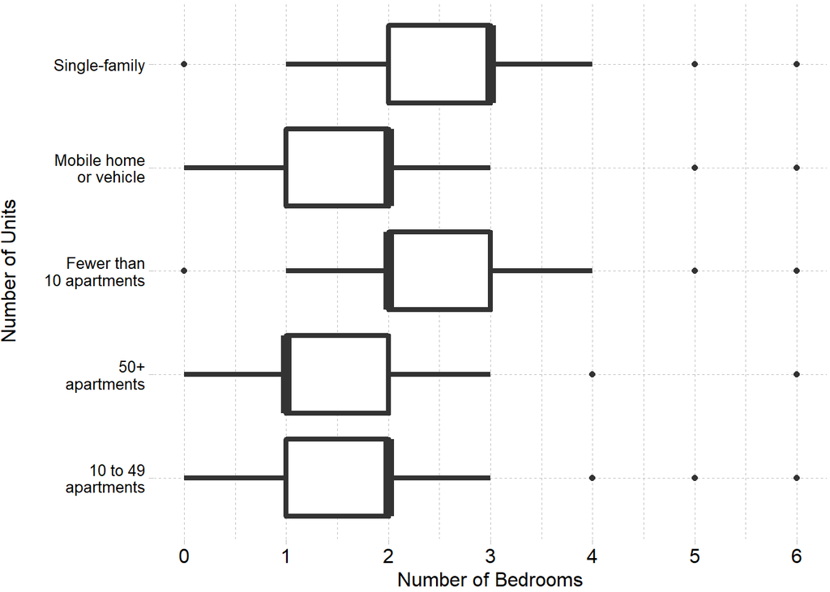

```r
ggplot(hh_data1, aes(x=bedrooms , y = num_units)) +
  geom_boxplot(size = 1.5) +
  theme_pander() +
  theme(axis.text.x = element_text(size = 12)) +
  scale_x_continuous(name = "Number of Bedrooms",
                     breaks = seq(0,6, by =1)) +
  scale_y_discrete(name = "Number of Units\n")
```

##### There is a statistically significant relationship between Number of Units and Number of Bedrooms (<2e-16). Aside from mobile home or vehicle, lower density has more bedrooms, while higher density buildings have less bedrooms.

#### 5. Number of People and Household Type

```r
anova5 <- aov(num_persons ~ hh_type, data = hh_data1)
summary(anova5)
```

```
##                Df Sum Sq Mean Sq F value Pr(>F)
## hh_type         3  17393    5798    3934 <2e-16 ***
## Residuals   17918  26405       1
## ---
## Signif. codes:  0 '***' 0.001 '**' 0.01 '*' 0.05 '.' 0.1 ' ' 1
```

```r
differences5 <- TukeyHSD(anova5)

as_tibble(cbind(pair = row.names(differences5$num_persons),
                differences5$hh_type))
```

```
## # A tibble: 6 x 4
##     diff    lwr    upr      `p adj`
##    <dbl>  <dbl>  <dbl>        <dbl>
## 1  2.60   2.53   2.67  0.0000000337
## 2  1.64   1.57   1.72  0.0000000337
## 3  2.43   2.36   2.50  0.0000000337
## 4 -0.959 -1.03  -0.892 0.0000000337
## 5 -0.173 -0.233 -0.113 0.0000000337
## 6  0.786  0.716  0.856 0.0000000337
```

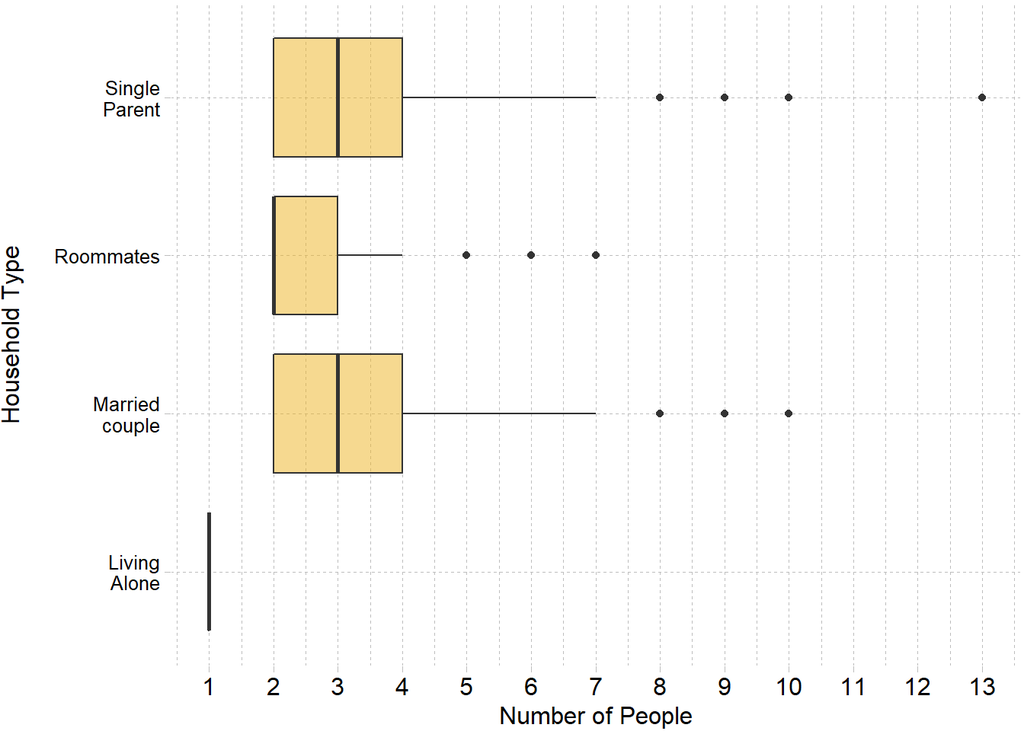

```r
ggplot(hh_data1, aes(x=num_persons , y = hh_type)) +
  geom_boxplot(fill = "goldenrod2", alpha = 0.5) +
  theme_pander() +
  theme(axis.text.x = element_text(size = 12)) +
  scale_x_continuous(name = "Number of People",
                     breaks = seq(0,14, by =1)) +
  scale_y_discrete(name = "Household Type\n")
```

##### There is a statistically significant relationship between Household Type and Number of People (<2e-16). Living alone already indicates the number of people in the home, but it is interesting to see that married couples and single parents have almost the same ranges, even in the outliers.

#### 6. Number of People and Number of Units

```r
anova6 <- aov(num_persons ~ num_units, data = hh_data1)
summary(anova6)
```

```
##                Df Sum Sq Mean Sq F value Pr(>F)
## num_units       4   3659   914.7   408.3 <2e-16 ***
## Residuals   17917  40140     2.2
## ---
## Signif. codes:  0 '***' 0.001 '**' 0.01 '*' 0.05 '.' 0.1 ' ' 1
```

```r
differences6 <- TukeyHSD(anova6)

as_tibble(cbind(pair = row.names(differences6$num_persons),
                differences6$num_units))
```

```
## # A tibble: 10 x 4
##       diff     lwr    upr      `p adj`
##      <dbl>   <dbl>  <dbl>        <dbl>
##  1 -0.0829 -0.197  0.0314 0.276
##  2  0.829   0.743  0.916  0.0000000337
##  3  0.568  -0.0384 1.18   0.0789
##  4  1.19    1.08   1.30   0.0000000337
##  5  0.912   0.817  1.01   0.0000000337
##  6  0.651   0.0432 1.26   0.0287
##  7  1.27    1.16   1.39   0.0000000337
##  8 -0.261  -0.864  0.343  0.764
##  9  0.361   0.277  0.446  0.0000000337
## 10  0.622   0.0154 1.23   0.0412
```

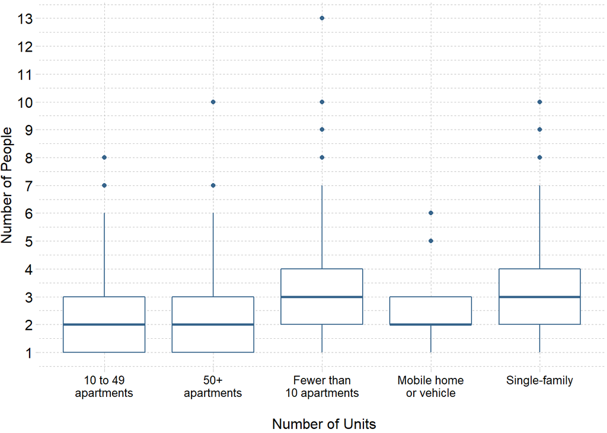

```r
ggplot(hh_data1, aes(y=num_persons , x = num_units)) +
  geom_boxplot(color = "steelblue4") +
  theme_pander() +
  theme(axis.text.y = element_text(size = 12)) +
  scale_x_discrete(name = "\n Number of Units") +
  scale_y_continuous(name = "Number of People",
                     breaks = seq(0, 14, by = 1))
```

##### There is a statistically significant relationship between Number of Units and Number of People (<2e-16). Similar to number of bedrooms above, lower density buildings have more people.

#### 7. Time Lived There and Household Type

```r
anova7 <- aov(move_in ~ hh_type, data = hh_data1)
summary(anova7)
```

```
##                Df Sum Sq Mean Sq F value Pr(>F)
## hh_type         3  31699   10566   257.9 <2e-16 ***
## Residuals   17918 734201      41
## ---
## Signif. codes:  0 '***' 0.001 '**' 0.01 '*' 0.05 '.' 0.1 ' ' 1
```

```r
differences7 <- TukeyHSD(anova7)

as_tibble(cbind(pair = row.names(differences7$move_in),
                differences7$hh_type))
```

```
## # A tibble: 6 x 4
##     diff       lwr    upr      `p adj`
##    <dbl>     <dbl>  <dbl>        <dbl>
## 1 -1.23  -1.58     -0.886 0.0000000337
## 2 -4.02  -4.42     -3.63  0.0000000337
## 3 -0.915 -1.28     -0.552 0.0000000343
## 4 -2.79  -3.14     -2.44  0.0000000337
## 5  0.317  0.000970  0.634 0.0490
## 6  3.11   2.74      3.48  0.0000000337
```

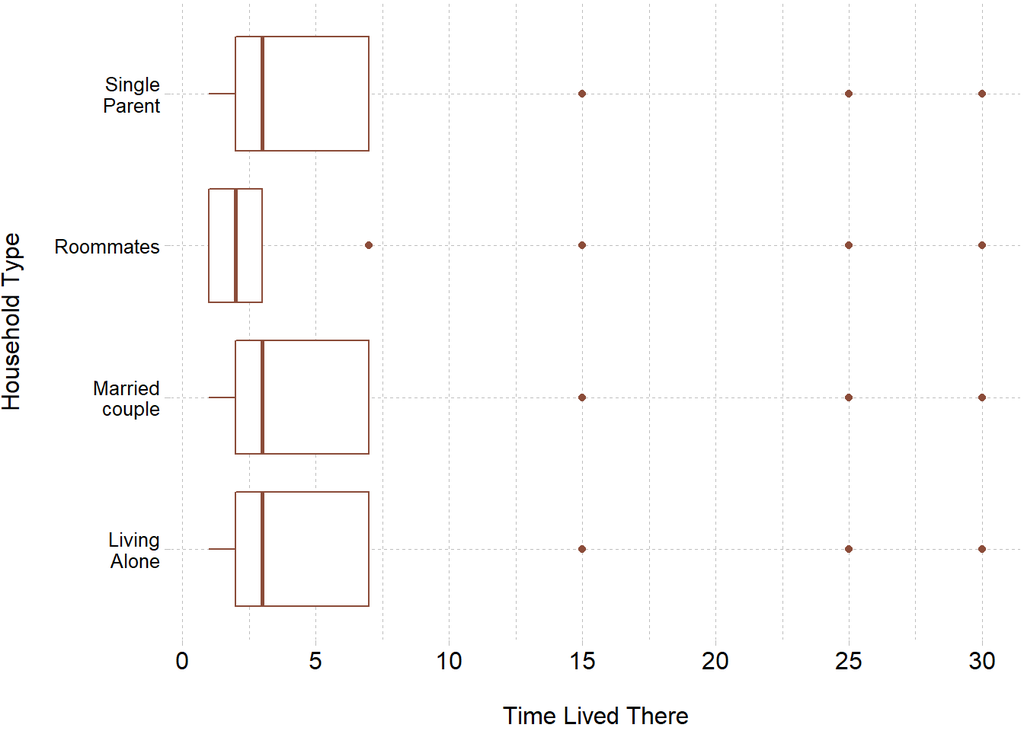

```r
ggplot(hh_data1, aes(x=move_in , y = hh_type)) +
  geom_boxplot(color = "salmon4") +
  theme_pander() +
  theme(axis.text.x = element_text(size = 12)) +
  scale_x_continuous(name = "\nTime Lived There",
                     breaks = seq(0, 30, by = 5)) +
  scale_y_discrete(name = "Household Type\n")
```

##### There is a statistically significant relationship between Household Type and Time Lived There (<2e-16). All but roommates share the same range, median, and outliers.

#### 8. Time Lived There and Number of Units

```r
anova8 <- aov(move_in ~ num_units, data = hh_data1)
summary(anova8)
```

```
##                Df Sum Sq Mean Sq F value Pr(>F)
## num_units       4   3503   875.8   20.58 <2e-16 ***
## Residuals   17917 762397    42.6
## ---
## Signif. codes:  0 '***' 0.001 '**' 0.01 '*' 0.05 '.' 0.1 ' ' 1
```

```r
differences8 <- TukeyHSD(anova8)

as_tibble(cbind(pair = row.names(differences8$move_in),
                differences8$num_units))
```

```
## # A tibble: 10 x 4
##       diff    lwr   upr      `p adj`
##      <dbl>  <dbl> <dbl>        <dbl>
##  1 -0.0614 -0.559 0.436 0.997
##  2  0.739   0.362 1.12  0.000000947
##  3  0.0632 -2.58  2.71  1.00
##  4  1.24    0.779 1.70  0.0000000337
##  5  0.800   0.386 1.21  0.00000141
##  6  0.125  -2.53  2.77  1.00
##  7  1.30    0.810 1.79  0.0000000337
##  8 -0.676  -3.31  1.95  0.956
##  9  0.501   0.133 0.869 0.00193
## 10  1.18   -1.47  3.82  0.743
```

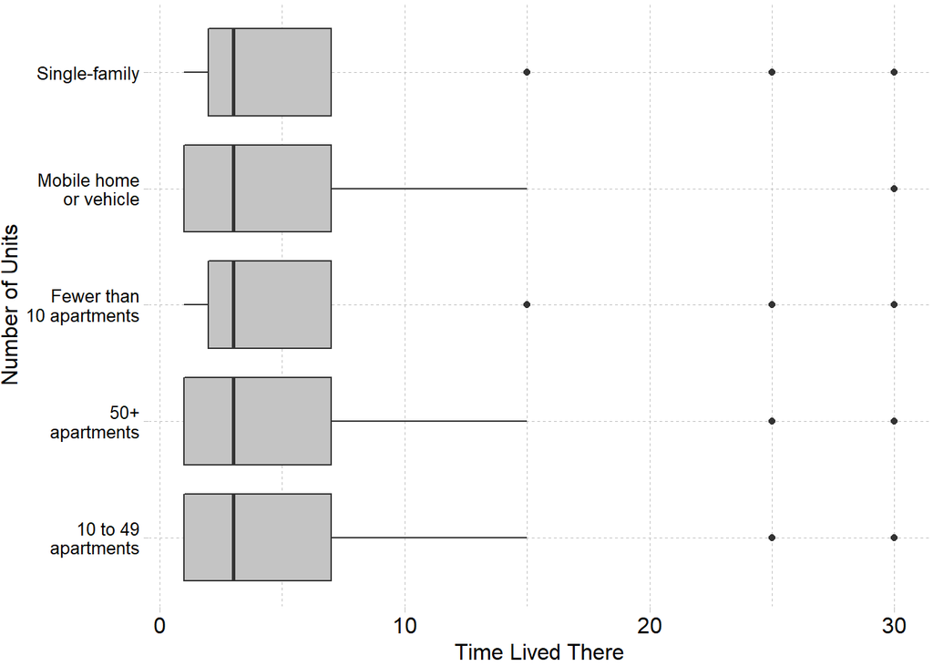

```r
ggplot(hh_data1, aes(x=move_in , y = num_units)) +
  geom_boxplot(fill = "gray77") +
  theme_pander() +
  theme(axis.text.x = element_text(size = 12)) +
  scale_x_continuous(name = "Time Lived There") +
  scale_y_discrete(name = "Number of Units")
```

##### There is a statistically significant relationship between Number of Units and Time Lived There (<2e-16). All have the same upper quartile and median!

#### 9. Gross Rent and Household Type

```r
anova9 <- aov(gross_rent ~ hh_type, data = hh_data1)
summary(anova7)
```

[output not shown]

```r
differences9 <- TukeyHSD(anova9)

as_tibble(cbind(pair = row.names(differences9$gross_rent),
                differences9$hh_type))
```

```
## # A tibble: 6 x 4
##    diff   lwr   upr      `p adj`
##   <dbl> <dbl> <dbl>        <dbl>
## 1  536.  494.  578. 0.0000000337
## 2  878.  831.  925. 0.0000000337
## 3  239.  195.  283. 0.0000000337
## 4  342.  300.  384. 0.0000000337
## 5 -297. -335. -259. 0.0000000337
## 6 -639. -683. -595. 0.0000000337
```

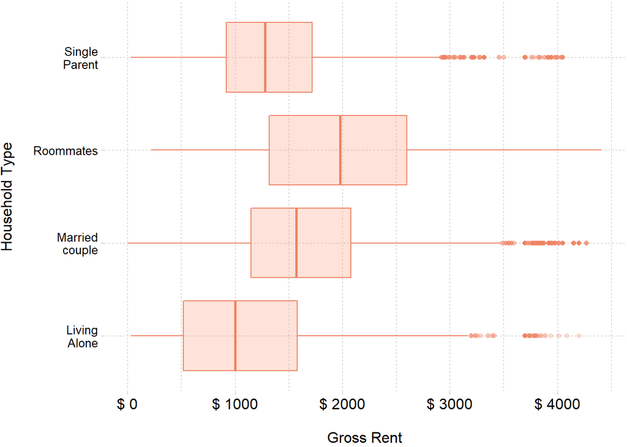

```r
ggplot(hh_data1, aes(x=gross_rent , y = hh_type)) +
  geom_boxplot(color = "salmon2", fill = "salmon1", alpha = 0.25) +
  theme_pander() +
  theme(axis.text.x = element_text(size = 12)) +
  scale_x_continuous(name = "\nGross Rent",
                     breaks = seq(0, 5000, by = 1000),
                     label = paste("$", (prettyNum(seq(0, 5000, by = 1000))))) +
  scale_y_discrete(name = "Household Type\n")
```

##### There is a statistically significant relationship between Household Type and Gross Rent (<2e-16). This would be interesting to compare to the number of bedrooms, as that usually has a factor on gross rent. There are also a lot of outliers.

#### 10. Gross Rent and Number of Units

```r
anova10 <- aov(gross_rent ~ num_units, data = hh_data1)
summary(anova10)
```

```
##                Df    Sum Sq  Mean Sq F value Pr(>F)
## num_units       4 1.606e+08 40158838   59.77 <2e-16 ***
## Residuals   17917 1.204e+10   671931
## ---
## Signif. codes:  0 '***' 0.001 '**' 0.01 '*' 0.05 '.' 0.1 ' ' 1
```

```r
differences10 <- TukeyHSD(anova10)

as_tibble(cbind(pair = row.names(differences10$gross_rent),
                differences10$num_units))
```

```
## # A tibble: 10 x 4
##       diff    lwr     upr      `p adj`
##      <dbl>  <dbl>   <dbl>        <dbl>
##  1  197.    135.   260.   0.0000000337
##  2    7.90  -39.5   55.3  0.991
##  3 -144.   -476.   188.   0.761
##  4  221.    163.   279.   0.0000000337
##  5 -189.   -241.  -137.   0.0000000337
##  6 -341.   -674.    -8.45 0.0412
##  7   23.7   -38.0   85.5  0.832
##  8 -152.   -483.   178.   0.719
##  9  213.    167.   259.   0.0000000337
## 10  365.     33.0  697.   0.0227
```

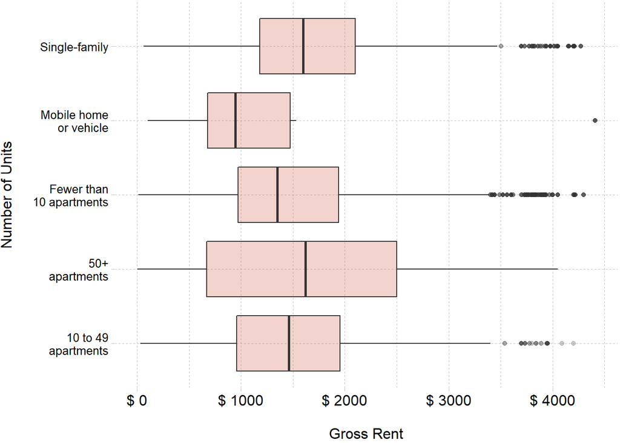

```r
ggplot(hh_data1, aes(x=gross_rent , y = num_units)) +
  geom_boxplot(fill = "tomato3", alpha = 0.25) +
  theme_pander() +
  theme(axis.text.x = element_text(size = 12)) +
  scale_x_continuous(name = "\nGross Rent",
                     breaks = seq(0, 5000, by = 1000),
                     label = paste("$", (prettyNum(seq(0, 5000, by = 1000))))) +
  scale_y_discrete(name = "Number of Units\n")
```

##### There is a statistically significant relationship between Number of Units and Gross Rent (<2e-16). What is the rent for Mobile home or vehicle? Expenses/insurance? Also interesting to see that 50+ apartments has a very wide interquartile range.